# examples_0408_B

Let $f$ represent a quartic (4th degree) polynomial with integer coefficients.

$$f(x)~=~{3}x^{4}+{4}x^{3}-{97}x^{2}-{244}x+{204}$$

One of the roots is $-4+i$, where $i=\sqrt{-1}$.

$$f(-4+i)~=~0$$

This quartic polynomial has at least 1 rational root. Find all the rational roots.

$-1$$-2$$-3$$-4$$-5$$-6$$-7$$-8$$-9$$\frac{-1}{2}$$\frac{-1}{3}$$\frac{-1}{4}$$\frac{-1}{5}$$\frac{-1}{6}$$\frac{-1}{7}$$\frac{-1}{8}$$\frac{-1}{9}$$\frac{-2}{3}$$\frac{-2}{5}$$\frac{-2}{7}$$\frac{-2}{9}$$\frac{-3}{2}$$\frac{-3}{4}$$\frac{-3}{5}$$\frac{-3}{7}$$\frac{-3}{8}$$\frac{-4}{3}$$\frac{-4}{5}$$\frac{-4}{7}$$\frac{-4}{9}$$\frac{-5}{2}$$\frac{-5}{3}$$\frac{-5}{4}$$\frac{-5}{6}$$\frac{-5}{7}$$\frac{-5}{8}$$\frac{-5}{9}$$\frac{-6}{5}$$\frac{-6}{7}$$\frac{-7}{2}$$\frac{-7}{3}$$\frac{-7}{4}$$\frac{-7}{5}$$\frac{-7}{6}$$\frac{-7}{8}$$\frac{-7}{9}$$\frac{-8}{3}$$\frac{-8}{5}$$\frac{-8}{7}$$\frac{-8}{9}$$\frac{-9}{2}$$\frac{-9}{4}$$\frac{-9}{5}$$\frac{-9}{7}$$\frac{1}{2}$$\frac{1}{3}$$\frac{1}{4}$$\frac{1}{5}$$\frac{1}{6}$$\frac{1}{7}$$\frac{1}{8}$$\frac{1}{9}$$\frac{2}{3}$$\frac{2}{5}$$\frac{2}{7}$$\frac{2}{9}$$\frac{3}{2}$$\frac{3}{4}$$\frac{3}{5}$$\frac{3}{7}$$\frac{3}{8}$$\frac{4}{3}$$\frac{4}{5}$$\frac{4}{7}$$\frac{4}{9}$$\frac{5}{2}$$\frac{5}{3}$$\frac{5}{4}$$\frac{5}{6}$$\frac{5}{7}$$\frac{5}{8}$$\frac{5}{9}$$\frac{6}{5}$$\frac{6}{7}$$\frac{7}{2}$$\frac{7}{3}$$\frac{7}{4}$$\frac{7}{5}$$\frac{7}{6}$$\frac{7}{8}$$\frac{7}{9}$$\frac{8}{3}$$\frac{8}{5}$$\frac{8}{7}$$\frac{8}{9}$$\frac{9}{2}$$\frac{9}{4}$$\frac{9}{5}$$\frac{9}{7}$$1$$2$$3$$4$$5$$6$$7$$8$$9$

We know that complex roots show up as complex-conjugate pairs. So, since $-4+i$ is a root, we also know $-4-i$ is another root. This accounts for two roots.

The [fundamental theorem of algebra](https://en.wikipedia.org/wiki/Fundamental_theorem_of_algebra) promises "every non-zero, single-variable, degree n polynomial with complex coefficients has, counted with multiplicity, exactly n complex roots."

So, we know there will be a total of 4 roots.

Thus, we should be able to express $f(x)$ in a semi-factored form (with yet to be determined coefficients $a$ and $b$ and $c$).

$$f(x)~=~(ax^2+bx+c)(x-(-4+i))(x-(-4-i))$$

Distribute the negatives across the inner parentheses.

$$f(x)~=~(ax^2+bx+c)(x+4-i)(x+4+i)$$

Now use a box to multiply the two complex factors.

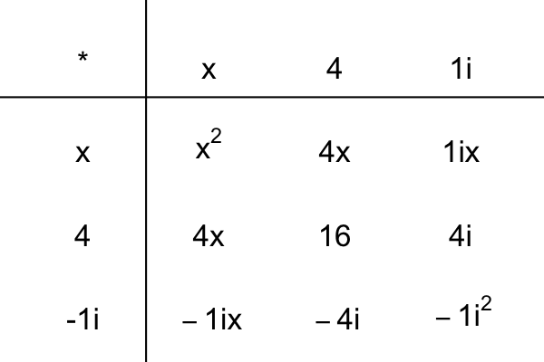

Remember, $i^2=-1$, so $-1i^2=1$. Combine like terms.

$$f(x)~=~(ax^2+bx+c)(x^2+8x+17)$$

Now... we know this semi-factored form and the standard form are equivalent expressions.

$$(ax^2+bx+c)(x^2+8x+17)~\equiv~{3}x^{4}+{4}x^{3}-{97}x^{2}-{244}x+{204}$$

So, we can divide both sides by $x^{2}+{8}x+{17}$.

$$ax^2+bx+c~=~\frac{{3}x^{4}+{4}x^{3}-{97}x^{2}-{244}x+{204}}{x^{2}+{8}x+{17}}$$

Use the box method to divide.

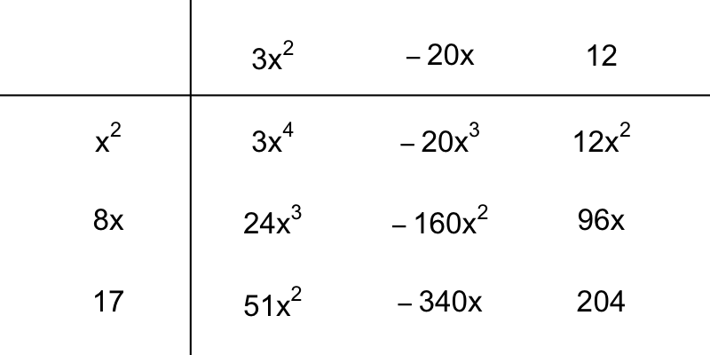

So,

$$f(x)~=~({3}x^{2}-{20}x+{12})(x^{2}+{8}x+{17})$$

We have expressed the quartic polynomial as the product of two quadratic polynomials. Remember, our goal is to find solutions to $f(x)=0$. We already know that $x=-4+i$ and $x=-4-i$ are solutions, and those two roots correspond to the factor $x^{2}+{8}x+{17}$ equaling 0. By setting the other quadratic factor, ${3}x^{2}-{20}x+{12}$, equal to zero, we can find the other roots.

$${3}x^{2}-{20}x+{12}=0$$

Use the quadratic formula: if $ax^2+bx+c=0$ then $x=\frac{-b\pm\sqrt{b^2-4ac}}{2a}$.

$$x=\frac{-(-20)\pm\sqrt{(-20)^2-4(3)(12)}}{2(3)}$$

Simplify.

$$x=\frac{20\pm\sqrt{400-144}}{6}$$

Simplify.

$$x=\frac{20\pm\sqrt{256}}{6}$$

Simplify.

$$x=\frac{20\pm16}{6}$$

Split into two different fraction.

$$\begin{align}
x&=\frac{20+16}{6} &&& x&=\frac{20-16}{6} \\\\
x&=\frac{36}{6} &&& x&=\frac{4}{6} \\\\
x&=6 &&& x&=\frac{2}{3}
\end{align}$$

Now we know all four roots. We could express $f$ in fully factored form.

$$f(x)~=~(x-{6})({3}x-{2})(x-(-4+i))(x-(-4-i))$$

Or, if you are not into complex factors, you could also express $f$ as factored as possible with integer coefficients.

$$f(x)~=~(x-{6})({3}x-{2})(x^{2}+{8}x+{17})$$

Anyway, the two rational roots are $6$ and $\frac{2}{3}$.

Let $f$ represent a quartic (4th degree) polynomial with integer coefficients.

$$f(x)~=~{8}x^{4}+{2}x^{3}-{27}x^{2}-{58}x-{30}$$

One of the roots is $-1+i$, where $i=\sqrt{-1}$.

$$f(-1+i)~=~0$$

This quartic polynomial has at least 1 rational root. Find all the rational roots.

$-1$$-2$$-3$$-4$$-5$$-6$$-7$$-8$$-9$$\frac{-1}{2}$$\frac{-1}{3}$$\frac{-1}{4}$$\frac{-1}{5}$$\frac{-1}{6}$$\frac{-1}{7}$$\frac{-1}{8}$$\frac{-1}{9}$$\frac{-2}{3}$$\frac{-2}{5}$$\frac{-2}{7}$$\frac{-2}{9}$$\frac{-3}{2}$$\frac{-3}{4}$$\frac{-3}{5}$$\frac{-3}{7}$$\frac{-3}{8}$$\frac{-4}{3}$$\frac{-4}{5}$$\frac{-4}{7}$$\frac{-4}{9}$$\frac{-5}{2}$$\frac{-5}{3}$$\frac{-5}{4}$$\frac{-5}{6}$$\frac{-5}{7}$$\frac{-5}{8}$$\frac{-5}{9}$$\frac{-6}{5}$$\frac{-6}{7}$$\frac{-7}{2}$$\frac{-7}{3}$$\frac{-7}{4}$$\frac{-7}{5}$$\frac{-7}{6}$$\frac{-7}{8}$$\frac{-7}{9}$$\frac{-8}{3}$$\frac{-8}{5}$$\frac{-8}{7}$$\frac{-8}{9}$$\frac{-9}{2}$$\frac{-9}{4}$$\frac{-9}{5}$$\frac{-9}{7}$$\frac{1}{2}$$\frac{1}{3}$$\frac{1}{4}$$\frac{1}{5}$$\frac{1}{6}$$\frac{1}{7}$$\frac{1}{8}$$\frac{1}{9}$$\frac{2}{3}$$\frac{2}{5}$$\frac{2}{7}$$\frac{2}{9}$$\frac{3}{2}$$\frac{3}{4}$$\frac{3}{5}$$\frac{3}{7}$$\frac{3}{8}$$\frac{4}{3}$$\frac{4}{5}$$\frac{4}{7}$$\frac{4}{9}$$\frac{5}{2}$$\frac{5}{3}$$\frac{5}{4}$$\frac{5}{6}$$\frac{5}{7}$$\frac{5}{8}$$\frac{5}{9}$$\frac{6}{5}$$\frac{6}{7}$$\frac{7}{2}$$\frac{7}{3}$$\frac{7}{4}$$\frac{7}{5}$$\frac{7}{6}$$\frac{7}{8}$$\frac{7}{9}$$\frac{8}{3}$$\frac{8}{5}$$\frac{8}{7}$$\frac{8}{9}$$\frac{9}{2}$$\frac{9}{4}$$\frac{9}{5}$$\frac{9}{7}$$1$$2$$3$$4$$5$$6$$7$$8$$9$

We know that complex roots show up as complex-conjugate pairs. So, since $-1+i$ is a root, we also know $-1-i$ is another root. This accounts for two roots.

The [fundamental theorem of algebra](https://en.wikipedia.org/wiki/Fundamental_theorem_of_algebra) promises "every non-zero, single-variable, degree n polynomial with complex coefficients has, counted with multiplicity, exactly n complex roots."

So, we know there will be a total of 4 roots.

Thus, we should be able to express $f(x)$ in a semi-factored form (with yet to be determined coefficients $a$ and $b$ and $c$).

$$f(x)~=~(ax^2+bx+c)(x-(-1+i))(x-(-1-i))$$

Distribute the negatives across the inner parentheses.

$$f(x)~=~(ax^2+bx+c)(x+1-i)(x+1+i)$$

Now use a box to multiply the two complex factors.

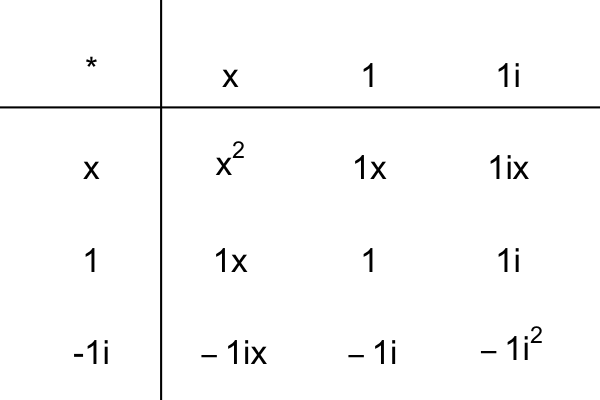

Remember, $i^2=-1$, so $-1i^2=1$. Combine like terms.

$$f(x)~=~(ax^2+bx+c)(x^2+2x+2)$$

Now... we know this semi-factored form and the standard form are equivalent expressions.

$$(ax^2+bx+c)(x^2+2x+2)~\equiv~{8}x^{4}+{2}x^{3}-{27}x^{2}-{58}x-{30}$$

So, we can divide both sides by $x^{2}+{2}x+{2}$.

$$ax^2+bx+c~=~\frac{{8}x^{4}+{2}x^{3}-{27}x^{2}-{58}x-{30}}{x^{2}+{2}x+{2}}$$

Use the box method to divide.

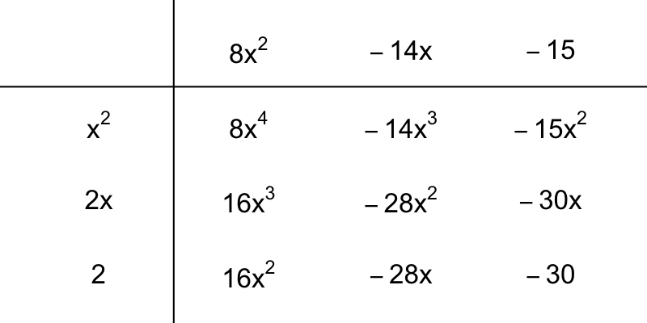

So,

$$f(x)~=~({8}x^{2}-{14}x-{15})(x^{2}+{2}x+{2})$$

We have expressed the quartic polynomial as the product of two quadratic polynomials. Remember, our goal is to find solutions to $f(x)=0$. We already know that $x=-1+i$ and $x=-1-i$ are solutions, and those two roots correspond to the factor $x^{2}+{2}x+{2}$ equaling 0. By setting the other quadratic factor, ${8}x^{2}-{14}x-{15}$, equal to zero, we can find the other roots.

$${8}x^{2}-{14}x-{15}=0$$

Use the quadratic formula: if $ax^2+bx+c=0$ then $x=\frac{-b\pm\sqrt{b^2-4ac}}{2a}$.

$$x=\frac{-(-14)\pm\sqrt{(-14)^2-4(8)(-15)}}{2(8)}$$

Simplify.

$$x=\frac{14\pm\sqrt{196+480}}{16}$$

Simplify.

$$x=\frac{14\pm\sqrt{676}}{16}$$

Simplify.

$$x=\frac{14\pm26}{16}$$

Split into two different fraction.

$$\begin{align}
x&=\frac{14+26}{16} &&& x&=\frac{14-26}{16} \\\\
x&=\frac{40}{16} &&& x&=\frac{-12}{16} \\\\
x&=\frac{5}{2} &&& x&=\frac{-3}{4}
\end{align}$$

Now we know all four roots. We could express $f$ in fully factored form.

$$f(x)~=~({4}x+{3})({2}x-{5})(x-(-1+i))(x-(-1-i))$$

Or, if you are not into complex factors, you could also express $f$ as factored as possible with integer coefficients.

$$f(x)~=~({4}x+{3})({2}x-{5})(x^{2}+{2}x+{2})$$

Anyway, the two rational roots are $\frac{-3}{4}$ and $\frac{5}{2}$.

Let $f$ represent a quartic (4th degree) polynomial with integer coefficients.

$$f(x)~=~{12}x^{4}+{25}x^{3}-{9}x^{2}-{68}x-{70}$$

One of the roots is $-1-i$, where $i=\sqrt{-1}$.

$$f(-1-i)~=~0$$

This quartic polynomial has at least 1 rational root. Find all the rational roots.

$-1$$-2$$-3$$-4$$-5$$-6$$-7$$-8$$-9$$\frac{-1}{2}$$\frac{-1}{3}$$\frac{-1}{4}$$\frac{-1}{5}$$\frac{-1}{6}$$\frac{-1}{7}$$\frac{-1}{8}$$\frac{-1}{9}$$\frac{-2}{3}$$\frac{-2}{5}$$\frac{-2}{7}$$\frac{-2}{9}$$\frac{-3}{2}$$\frac{-3}{4}$$\frac{-3}{5}$$\frac{-3}{7}$$\frac{-3}{8}$$\frac{-4}{3}$$\frac{-4}{5}$$\frac{-4}{7}$$\frac{-4}{9}$$\frac{-5}{2}$$\frac{-5}{3}$$\frac{-5}{4}$$\frac{-5}{6}$$\frac{-5}{7}$$\frac{-5}{8}$$\frac{-5}{9}$$\frac{-6}{5}$$\frac{-6}{7}$$\frac{-7}{2}$$\frac{-7}{3}$$\frac{-7}{4}$$\frac{-7}{5}$$\frac{-7}{6}$$\frac{-7}{8}$$\frac{-7}{9}$$\frac{-8}{3}$$\frac{-8}{5}$$\frac{-8}{7}$$\frac{-8}{9}$$\frac{-9}{2}$$\frac{-9}{4}$$\frac{-9}{5}$$\frac{-9}{7}$$\frac{1}{2}$$\frac{1}{3}$$\frac{1}{4}$$\frac{1}{5}$$\frac{1}{6}$$\frac{1}{7}$$\frac{1}{8}$$\frac{1}{9}$$\frac{2}{3}$$\frac{2}{5}$$\frac{2}{7}$$\frac{2}{9}$$\frac{3}{2}$$\frac{3}{4}$$\frac{3}{5}$$\frac{3}{7}$$\frac{3}{8}$$\frac{4}{3}$$\frac{4}{5}$$\frac{4}{7}$$\frac{4}{9}$$\frac{5}{2}$$\frac{5}{3}$$\frac{5}{4}$$\frac{5}{6}$$\frac{5}{7}$$\frac{5}{8}$$\frac{5}{9}$$\frac{6}{5}$$\frac{6}{7}$$\frac{7}{2}$$\frac{7}{3}$$\frac{7}{4}$$\frac{7}{5}$$\frac{7}{6}$$\frac{7}{8}$$\frac{7}{9}$$\frac{8}{3}$$\frac{8}{5}$$\frac{8}{7}$$\frac{8}{9}$$\frac{9}{2}$$\frac{9}{4}$$\frac{9}{5}$$\frac{9}{7}$$1$$2$$3$$4$$5$$6$$7$$8$$9$

We know that complex roots show up as complex-conjugate pairs. So, since $-1-i$ is a root, we also know $-1+i$ is another root. This accounts for two roots.

The [fundamental theorem of algebra](https://en.wikipedia.org/wiki/Fundamental_theorem_of_algebra) promises "every non-zero, single-variable, degree n polynomial with complex coefficients has, counted with multiplicity, exactly n complex roots."

So, we know there will be a total of 4 roots.

Thus, we should be able to express $f(x)$ in a semi-factored form (with yet to be determined coefficients $a$ and $b$ and $c$).

$$f(x)~=~(ax^2+bx+c)(x-(-1-i))(x-(-1+i))$$

Distribute the negatives across the inner parentheses.

$$f(x)~=~(ax^2+bx+c)(x+1+i)(x+1-i)$$

Now use a box to multiply the two complex factors.

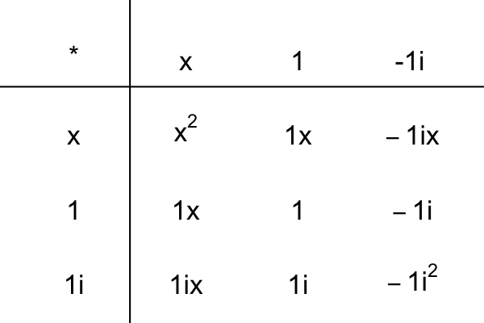

Remember, $i^2=-1$, so $-1i^2=1$. Combine like terms.

$$f(x)~=~(ax^2+bx+c)(x^2+2x+2)$$

Now... we know this semi-factored form and the standard form are equivalent expressions.

$$(ax^2+bx+c)(x^2+2x+2)~\equiv~{12}x^{4}+{25}x^{3}-{9}x^{2}-{68}x-{70}$$

So, we can divide both sides by $x^{2}+{2}x+{2}$.

$$ax^2+bx+c~=~\frac{{12}x^{4}+{25}x^{3}-{9}x^{2}-{68}x-{70}}{x^{2}+{2}x+{2}}$$

Use the box method to divide.

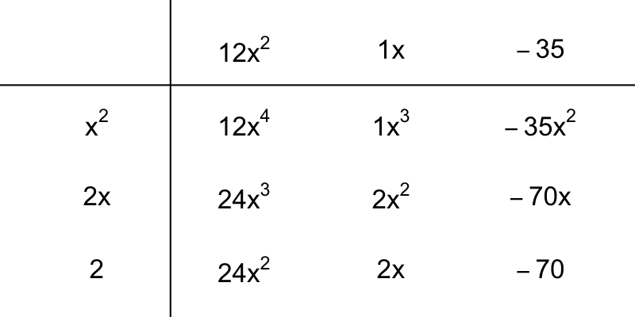

So,

$$f(x)~=~({12}x^{2}+x-{35})(x^{2}+{2}x+{2})$$

We have expressed the quartic polynomial as the product of two quadratic polynomials. Remember, our goal is to find solutions to $f(x)=0$. We already know that $x=-1-i$ and $x=-1+i$ are solutions, and those two roots correspond to the factor $x^{2}+{2}x+{2}$ equaling 0. By setting the other quadratic factor, ${12}x^{2}+x-{35}$, equal to zero, we can find the other roots.

$${12}x^{2}+x-{35}=0$$

Use the quadratic formula: if $ax^2+bx+c=0$ then $x=\frac{-b\pm\sqrt{b^2-4ac}}{2a}$.

$$x=\frac{-(1)\pm\sqrt{(1)^2-4(12)(-35)}}{2(12)}$$

Simplify.

$$x=\frac{-1\pm\sqrt{1+1680}}{24}$$

Simplify.

$$x=\frac{-1\pm\sqrt{1681}}{24}$$

Simplify.

$$x=\frac{-1\pm41}{24}$$

Split into two different fraction.

$$\begin{align}
x&=\frac{-1+41}{24} &&& x&=\frac{-1-41}{24} \\\\
x&=\frac{40}{24} &&& x&=\frac{-42}{24} \\\\
x&=\frac{5}{3} &&& x&=\frac{-7}{4}
\end{align}$$

Now we know all four roots. We could express $f$ in fully factored form.

$$f(x)~=~({3}x-{5})({4}x+{7})(x-(-1-i))(x-(-1+i))$$

Or, if you are not into complex factors, you could also express $f$ as factored as possible with integer coefficients.

$$f(x)~=~({3}x-{5})({4}x+{7})(x^{2}+{2}x+{2})$$

Anyway, the two rational roots are $\frac{5}{3}$ and $\frac{-7}{4}$.

Let $f$ represent a quartic (4th degree) polynomial with integer coefficients.

$$f(x)~=~{45}x^{4}+{62}x^{3}+{38}x^{2}-{48}x+{8}$$

One of the roots is $-1-i$, where $i=\sqrt{-1}$.

$$f(-1-i)~=~0$$

This quartic polynomial has at least 1 rational root. Find all the rational roots.

$-1$$-2$$-3$$-4$$-5$$-6$$-7$$-8$$-9$$\frac{-1}{2}$$\frac{-1}{3}$$\frac{-1}{4}$$\frac{-1}{5}$$\frac{-1}{6}$$\frac{-1}{7}$$\frac{-1}{8}$$\frac{-1}{9}$$\frac{-2}{3}$$\frac{-2}{5}$$\frac{-2}{7}$$\frac{-2}{9}$$\frac{-3}{2}$$\frac{-3}{4}$$\frac{-3}{5}$$\frac{-3}{7}$$\frac{-3}{8}$$\frac{-4}{3}$$\frac{-4}{5}$$\frac{-4}{7}$$\frac{-4}{9}$$\frac{-5}{2}$$\frac{-5}{3}$$\frac{-5}{4}$$\frac{-5}{6}$$\frac{-5}{7}$$\frac{-5}{8}$$\frac{-5}{9}$$\frac{-6}{5}$$\frac{-6}{7}$$\frac{-7}{2}$$\frac{-7}{3}$$\frac{-7}{4}$$\frac{-7}{5}$$\frac{-7}{6}$$\frac{-7}{8}$$\frac{-7}{9}$$\frac{-8}{3}$$\frac{-8}{5}$$\frac{-8}{7}$$\frac{-8}{9}$$\frac{-9}{2}$$\frac{-9}{4}$$\frac{-9}{5}$$\frac{-9}{7}$$\frac{1}{2}$$\frac{1}{3}$$\frac{1}{4}$$\frac{1}{5}$$\frac{1}{6}$$\frac{1}{7}$$\frac{1}{8}$$\frac{1}{9}$$\frac{2}{3}$$\frac{2}{5}$$\frac{2}{7}$$\frac{2}{9}$$\frac{3}{2}$$\frac{3}{4}$$\frac{3}{5}$$\frac{3}{7}$$\frac{3}{8}$$\frac{4}{3}$$\frac{4}{5}$$\frac{4}{7}$$\frac{4}{9}$$\frac{5}{2}$$\frac{5}{3}$$\frac{5}{4}$$\frac{5}{6}$$\frac{5}{7}$$\frac{5}{8}$$\frac{5}{9}$$\frac{6}{5}$$\frac{6}{7}$$\frac{7}{2}$$\frac{7}{3}$$\frac{7}{4}$$\frac{7}{5}$$\frac{7}{6}$$\frac{7}{8}$$\frac{7}{9}$$\frac{8}{3}$$\frac{8}{5}$$\frac{8}{7}$$\frac{8}{9}$$\frac{9}{2}$$\frac{9}{4}$$\frac{9}{5}$$\frac{9}{7}$$1$$2$$3$$4$$5$$6$$7$$8$$9$

We know that complex roots show up as complex-conjugate pairs. So, since $-1-i$ is a root, we also know $-1+i$ is another root. This accounts for two roots.

The [fundamental theorem of algebra](https://en.wikipedia.org/wiki/Fundamental_theorem_of_algebra) promises "every non-zero, single-variable, degree n polynomial with complex coefficients has, counted with multiplicity, exactly n complex roots."

So, we know there will be a total of 4 roots.

Thus, we should be able to express $f(x)$ in a semi-factored form (with yet to be determined coefficients $a$ and $b$ and $c$).

$$f(x)~=~(ax^2+bx+c)(x-(-1-i))(x-(-1+i))$$

Distribute the negatives across the inner parentheses.

$$f(x)~=~(ax^2+bx+c)(x+1+i)(x+1-i)$$

Now use a box to multiply the two complex factors.

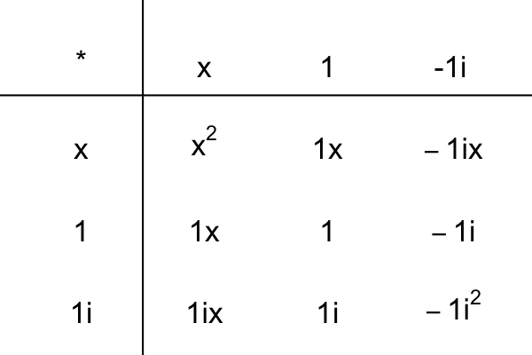

Remember, $i^2=-1$, so $-1i^2=1$. Combine like terms.

$$f(x)~=~(ax^2+bx+c)(x^2+2x+2)$$

Now... we know this semi-factored form and the standard form are equivalent expressions.

$$(ax^2+bx+c)(x^2+2x+2)~\equiv~{45}x^{4}+{62}x^{3}+{38}x^{2}-{48}x+{8}$$

So, we can divide both sides by $x^{2}+{2}x+{2}$.

$$ax^2+bx+c~=~\frac{{45}x^{4}+{62}x^{3}+{38}x^{2}-{48}x+{8}}{x^{2}+{2}x+{2}}$$

Use the box method to divide.

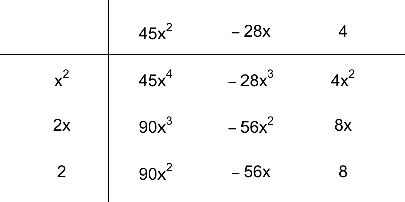

So,

$$f(x)~=~({45}x^{2}-{28}x+{4})(x^{2}+{2}x+{2})$$

We have expressed the quartic polynomial as the product of two quadratic polynomials. Remember, our goal is to find solutions to $f(x)=0$. We already know that $x=-1-i$ and $x=-1+i$ are solutions, and those two roots correspond to the factor $x^{2}+{2}x+{2}$ equaling 0. By setting the other quadratic factor, ${45}x^{2}-{28}x+{4}$, equal to zero, we can find the other roots.

$${45}x^{2}-{28}x+{4}=0$$

Use the quadratic formula: if $ax^2+bx+c=0$ then $x=\frac{-b\pm\sqrt{b^2-4ac}}{2a}$.

$$x=\frac{-(-28)\pm\sqrt{(-28)^2-4(45)(4)}}{2(45)}$$

Simplify.

$$x=\frac{28\pm\sqrt{784-720}}{90}$$

Simplify.

$$x=\frac{28\pm\sqrt{64}}{90}$$

Simplify.

$$x=\frac{28\pm8}{90}$$

Split into two different fraction.

$$\begin{align}
x&=\frac{28+8}{90} &&& x&=\frac{28-8}{90} \\\\
x&=\frac{36}{90} &&& x&=\frac{20}{90} \\\\
x&=\frac{2}{5} &&& x&=\frac{2}{9}
\end{align}$$

Now we know all four roots. We could express $f$ in fully factored form.

$$f(x)~=~({9}x-{2})({5}x-{2})(x-(-1-i))(x-(-1+i))$$

Or, if you are not into complex factors, you could also express $f$ as factored as possible with integer coefficients.

$$f(x)~=~({9}x-{2})({5}x-{2})(x^{2}+{2}x+{2})$$

Anyway, the two rational roots are $\frac{2}{9}$ and $\frac{2}{5}$.

Let $f$ represent a quartic (4th degree) polynomial with integer coefficients.

$$f(x)~=~x^{4}-{5}x^{3}+x^{2}-{229}x+{232}$$

One of the roots is $-2+5i$, where $i=\sqrt{-1}$.

$$f(-2+5i)~=~0$$

This quartic polynomial has at least 1 rational root. Find all the rational roots.

$-1$$-2$$-3$$-4$$-5$$-6$$-7$$-8$$-9$$\frac{-1}{2}$$\frac{-1}{3}$$\frac{-1}{4}$$\frac{-1}{5}$$\frac{-1}{6}$$\frac{-1}{7}$$\frac{-1}{8}$$\frac{-1}{9}$$\frac{-2}{3}$$\frac{-2}{5}$$\frac{-2}{7}$$\frac{-2}{9}$$\frac{-3}{2}$$\frac{-3}{4}$$\frac{-3}{5}$$\frac{-3}{7}$$\frac{-3}{8}$$\frac{-4}{3}$$\frac{-4}{5}$$\frac{-4}{7}$$\frac{-4}{9}$$\frac{-5}{2}$$\frac{-5}{3}$$\frac{-5}{4}$$\frac{-5}{6}$$\frac{-5}{7}$$\frac{-5}{8}$$\frac{-5}{9}$$\frac{-6}{5}$$\frac{-6}{7}$$\frac{-7}{2}$$\frac{-7}{3}$$\frac{-7}{4}$$\frac{-7}{5}$$\frac{-7}{6}$$\frac{-7}{8}$$\frac{-7}{9}$$\frac{-8}{3}$$\frac{-8}{5}$$\frac{-8}{7}$$\frac{-8}{9}$$\frac{-9}{2}$$\frac{-9}{4}$$\frac{-9}{5}$$\frac{-9}{7}$$\frac{1}{2}$$\frac{1}{3}$$\frac{1}{4}$$\frac{1}{5}$$\frac{1}{6}$$\frac{1}{7}$$\frac{1}{8}$$\frac{1}{9}$$\frac{2}{3}$$\frac{2}{5}$$\frac{2}{7}$$\frac{2}{9}$$\frac{3}{2}$$\frac{3}{4}$$\frac{3}{5}$$\frac{3}{7}$$\frac{3}{8}$$\frac{4}{3}$$\frac{4}{5}$$\frac{4}{7}$$\frac{4}{9}$$\frac{5}{2}$$\frac{5}{3}$$\frac{5}{4}$$\frac{5}{6}$$\frac{5}{7}$$\frac{5}{8}$$\frac{5}{9}$$\frac{6}{5}$$\frac{6}{7}$$\frac{7}{2}$$\frac{7}{3}$$\frac{7}{4}$$\frac{7}{5}$$\frac{7}{6}$$\frac{7}{8}$$\frac{7}{9}$$\frac{8}{3}$$\frac{8}{5}$$\frac{8}{7}$$\frac{8}{9}$$\frac{9}{2}$$\frac{9}{4}$$\frac{9}{5}$$\frac{9}{7}$$1$$2$$3$$4$$5$$6$$7$$8$$9$

We know that complex roots show up as complex-conjugate pairs. So, since $-2+5i$ is a root, we also know $-2-5i$ is another root. This accounts for two roots.

The [fundamental theorem of algebra](https://en.wikipedia.org/wiki/Fundamental_theorem_of_algebra) promises "every non-zero, single-variable, degree n polynomial with complex coefficients has, counted with multiplicity, exactly n complex roots."

So, we know there will be a total of 4 roots.

Thus, we should be able to express $f(x)$ in a semi-factored form (with yet to be determined coefficients $a$ and $b$ and $c$).

$$f(x)~=~(ax^2+bx+c)(x-(-2+5i))(x-(-2-5i))$$

Distribute the negatives across the inner parentheses.

$$f(x)~=~(ax^2+bx+c)(x+2-5i)(x+2+5i)$$

Now use a box to multiply the two complex factors.

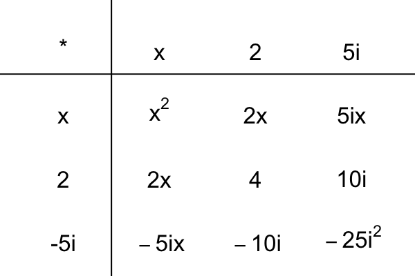

Remember, $i^2=-1$, so $-25i^2=25$. Combine like terms.

$$f(x)~=~(ax^2+bx+c)(x^2+4x+29)$$

Now... we know this semi-factored form and the standard form are equivalent expressions.

$$(ax^2+bx+c)(x^2+4x+29)~\equiv~x^{4}-{5}x^{3}+x^{2}-{229}x+{232}$$

So, we can divide both sides by $x^{2}+{4}x+{29}$.

$$ax^2+bx+c~=~\frac{x^{4}-{5}x^{3}+x^{2}-{229}x+{232}}{x^{2}+{4}x+{29}}$$

Use the box method to divide.

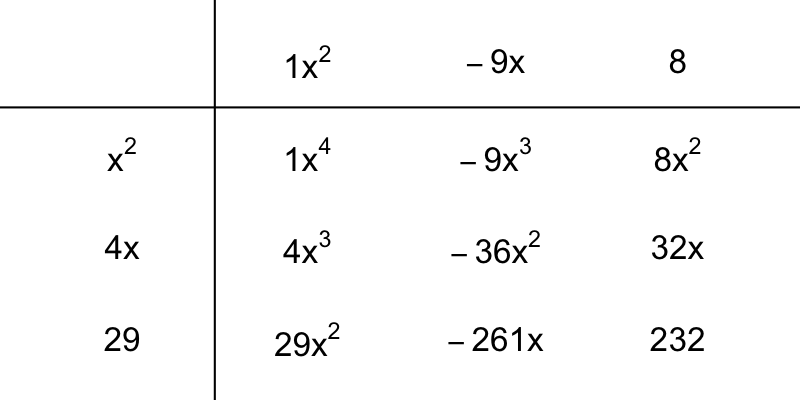

So,

$$f(x)~=~(x^{2}-{9}x+{8})(x^{2}+{4}x+{29})$$

We have expressed the quartic polynomial as the product of two quadratic polynomials. Remember, our goal is to find solutions to $f(x)=0$. We already know that $x=-2+5i$ and $x=-2-5i$ are solutions, and those two roots correspond to the factor $x^{2}+{4}x+{29}$ equaling 0. By setting the other quadratic factor, $x^{2}-{9}x+{8}$, equal to zero, we can find the other roots.

$$x^{2}-{9}x+{8}=0$$

Use the quadratic formula: if $ax^2+bx+c=0$ then $x=\frac{-b\pm\sqrt{b^2-4ac}}{2a}$.

$$x=\frac{-(-9)\pm\sqrt{(-9)^2-4(1)(8)}}{2(1)}$$

Simplify.

$$x=\frac{9\pm\sqrt{81-32}}{2}$$

Simplify.

$$x=\frac{9\pm\sqrt{49}}{2}$$

Simplify.

$$x=\frac{9\pm7}{2}$$

Split into two different fraction.

$$\begin{align}
x&=\frac{9+7}{2} &&& x&=\frac{9-7}{2} \\\\
x&=\frac{16}{2} &&& x&=\frac{2}{2} \\\\
x&=8 &&& x&=1
\end{align}$$

Now we know all four roots. We could express $f$ in fully factored form.

$$f(x)~=~(x-{8})(x-{1})(x-(-2+5i))(x-(-2-5i))$$

Or, if you are not into complex factors, you could also express $f$ as factored as possible with integer coefficients.

$$f(x)~=~(x-{8})(x-{1})(x^{2}+{4}x+{29})$$

Anyway, the two rational roots are $8$ and $1$.